# La diferencia entre la calidad de sueño y la adicción a internet entre estudiantes universitarios masculinos y femeninos

04 Mayo 2023

### Poblacion Objetiva : Estudiantes Universitarios

### Unidad muestral: Cualquier estudiante UTEC

### Tipo de muestreo: Muestreo por conveniencia

# Introducción:

### Relevancia

En la actualidad, el internet es una pieza fundamental en la vida diaria de las personas. Este ha conseguido proporcionar acceso a cualquier tipo de información de manera instantánea. Además permite que las personas se comuniquen independientemente de donde vivan y facilita distintas tareas volviéndose más accesibles a cualquier persona. No obstante, existen casos en los que su uso excesivo empieza a generar cierta dependencia en los usuarios, provocando el trastorno conocido como adicción a internet. Esta adicción está relacionada con varios trastornos psiquiátricos, teniendo uno como principal relacionado a la calidad de sueño. Este trastorno ha tomado mucha importancia debido a los problemas que este conlleva, afectando seriamente en la calidad de vida y productividad de las personas. Por lo general son muy pocos los estudios que abordan el tema de adicción a internet y trastornos de sueño.

```r
###### LIBRERIAS
if (! require (ggplot2)) {install.packages ('ggplot2')}
library(ggplot2)
if (! require (tidyr)) {install.packages ('tidyr')}
library(tidyr)
if (! require (lubridate)) {install.packages ('lubridate')}
library(lubridate)
if (! require (readr)) {install.packages ('readr')}
library(readr)
if (! require (tidyverse)) {install.packages ('tidyverse')}
library(tidyverse)
if (! require (dplyr)) {install.packages ('dplyr')}
library(dplyr)
```

```r
###### LEER CSV

datos <- read_csv("BASEDEDATOS.csv")
###### RENOMBRAR VARIABLES
names(datos) = c("Marca_Temporal", "Sorteo", "Edad", "Sexo", "Convivencia" , "Año_de_estudios","Curso_por_ciclo", "Conexion_internet", "Descuido_internet", "Conexion_humana", "Relacion_Usuarios_inter", "Queja_tiempo_conectado", "Calificaciones_internet", "Revisar_correo", "Trabajo_internet", "Defensiva_internet", "Pensamientos_agradables_internet", "Anticipa_conectado", "vida_sin_internet", "enoja_conectado", "no_dormir_internet", "imagina_estar_coectado", "un_min_mas", "tratar_de_dejarlo", "ocultarse_tiempo_conectado", "no_salir", "mal_no_bien_si_internet", "Hora_de_acostarse ", "Tiempo_de_dormir", "Hora_de_levantarse  ", "horas_de_dormir", "no_dormir_media_hora","despertar_denoche", "ir_baño", "respirar_mal", "toser_roncar", "frio", "calor", "pesadillas", "dolores", "otros", "calidad_sueño", "medicina_dormir", "somnolencia", "animo_actividad", "duerme_solo", "Indice_adiccion_internet","Categoria_adiccion","Indice_calidad_sueño","I1","Suma_I2","I2","I3","I4","Horas_dormidas","Horas_cama","eficiencia","Suma_I5","I5","I6","Suma_I7","I7", "Puntaje_total")
```

## Deberes de Proyecto

```r
df <- read_csv("prueba.csv")
df$Star <- dmy(df$Star)
df$End <- dmy(df$End)
```

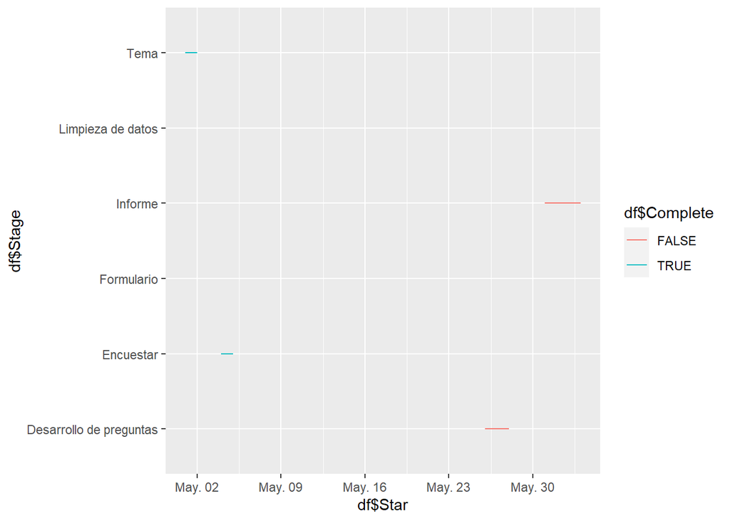

```r
ggplot2::ggplot(df, aes(x = df$Star, xend = df$End, y = df$Stage, yend = df$Stage, color = df$Complete)) + ggplot2::geom_segment()
```

## Deberes por integrante de proyecto

```r
dr <- read_csv("Responsabilidades.csv")
dr$Star <- dmy(dr$Star)
dr$End <- dmy(dr$End)
```

Diagrama de deberes por integrante

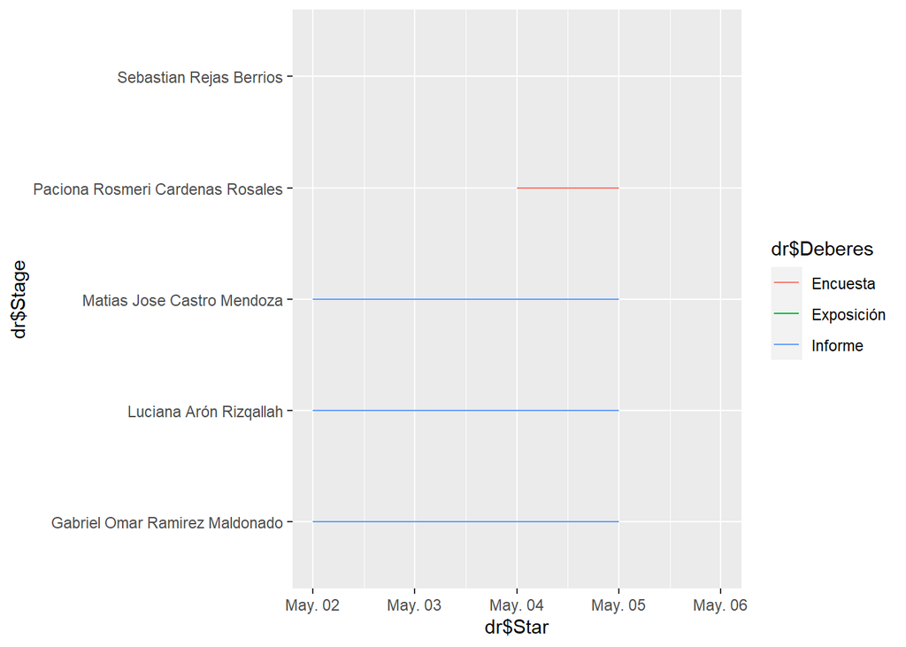

```r
ggplot2::ggplot(dr, aes(x = dr$Star, xend = dr$End, y = dr$Stage, yend = dr$Stage, color = dr$Deberes)) + ggplot2::geom_segment()
```

# Datos

### Población, muestra y muestreo

La población se va a centrar en estudiantes de la Universidad de tecnología e ingeniería - Utec.

### Variables

| **Pregunta** | **Variable** | **Tipo de variable** | **Restricciones** |
| --- | --- | --- | --- |
| ¿Cuál es su edad? | Edad | Numérica continua | Mayores a 15 años |
| ¿Cuál es su sexo? | Sexo | Categórica nominal | Masculino, Femenino y Prefiero no decirlo |
| ¿Con quien conviene? | Convivencia | Categórica nominal | Solo, padres, amigos u otros familiares |
| Año de estudio | Año de estudio | Numérica discreta | Entero no negativo |
| ¿Llevas todos los cursos que corresponden a este ciclo académico de tu malla curricular? | Curso por ciclo | Categórica nominal | si o no |
| Test de adicción a Internet | Tets de adicción a Internet | Categórica Ordinal | Entero no negativo |
| Durante el último mes. ¿Cuál ha sido, normalmente su hora de acostarse? | Hora de acostarse | Numérica continua | Entero no negativo |
| ¿Cuanto tiempo habrá tardado en dormirse, normalmente, las noches del ultimo mes? | Tiempo de dormir | Numérica continua | Entero no negativo |
| Test de calidad de sueño | Test de calidad de sueño | Categórica ordinal | Entero no negativo |
| Durante el último mes, ¿a qué hora se ha levantado habitualmente por la mañana? | Hora de levantarse | Numérica continua | Entero no negativo |

Debido a que nuestro tema involucra temas psicológicos como lo son las adicciones decidimos utilizar un test psicológico certificado para medir estas. La adición a la internet fue medida con el “Internet Addiction Test (IAT)” (Recopilado de: [Este enlace](https://www.elsevier.es/es-revista-trastornos-adictivos-182-articulo-analisis-propiedades-psicometricas-version-espanol-S1575097312700521) creado por Young y validado previamente al español en Chile, Colombia y España. Así mismo la calidad de sueño será definida según el “índice de Calidad del Sueño de Pittsburgh (PSQI)” (Recopilado de: [Este enlace](https://multimedia.elsevier.es/PublicationsMultimediaV1/item/multimedia/S021265671400122X:mmc1.pdf?idApp=UINPBA00004N) previamente Adaptado y validado por Colombia y Mexico.

El IAT cuenta con 20 ítems, cada uno se puede responder en una escala de 5 puntos, dando una puntuación total de 20 a 100. Se clasifica a la población en 3 rangos luego de haber realizado esta prueba: Usuario promedio(20 a 49 puntos), Usuarios problemáticos (50 a 79 puntos) y Usuarios adictos (80 a más puntos).

El PSQI cuenta con 21 preguntas agrupadas en 7 componentes de la calidad de sueño: eficiencia habitual del sueño, duración, perturbaciones, latencia, disfunción diaria debido a la somnolencia, calidad del sueño subjetiva y los medicamentos de uso general.

## Limpieza de base de datos

### Aun no es necesario realizarlo

## Análisis descriptivo

### Edad

```r
summary(datos$Edad)
```

```
##    Min. 1st Qu.  Median    Mean 3rd Qu.    Max.
##   16.00   18.00   20.00   20.89   22.00   55.00
```

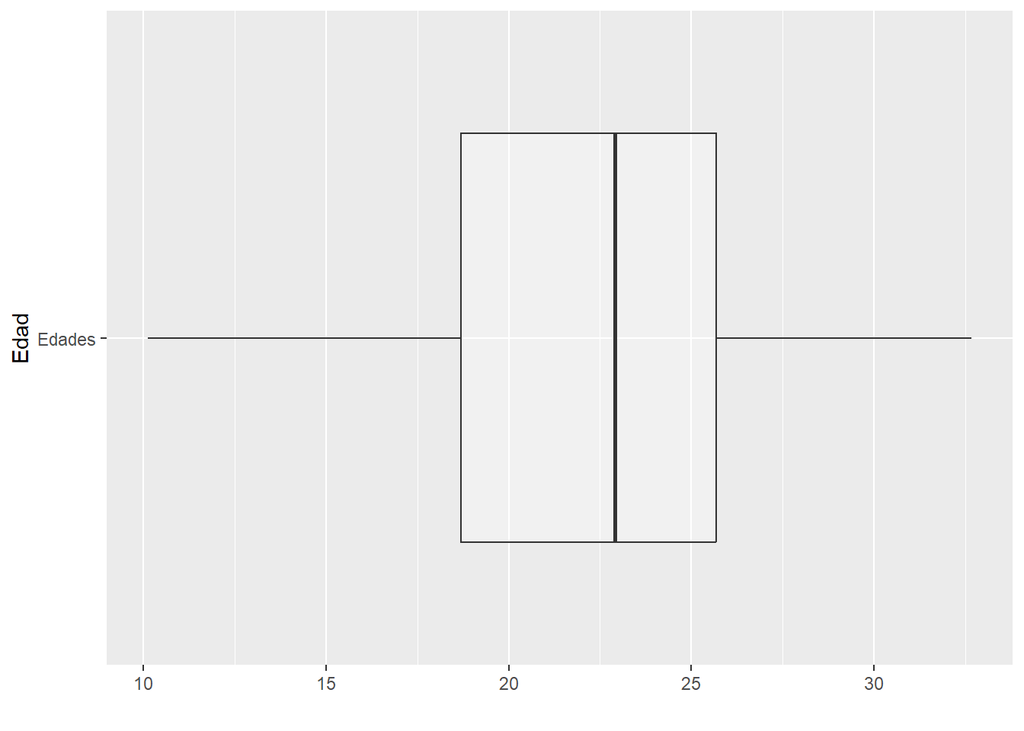

```r
###### CREAR DATAFRAME DE EDADES

Edades <- data.frame(
  Edad = c(rep("Edades", nrow(datos))),
  CantidadDeAlumnos = c(rnorm(nrow(datos), mean(datos$Edad), sd(datos$Edad)))
)

###### BOXPLOT DE EDADES

ggplot(Edades, aes(x=CantidadDeAlumnos, y= Edad), fill=Edad) +
    geom_boxplot(alpha=0.3) +
    xlab("")
```

### Convivencia

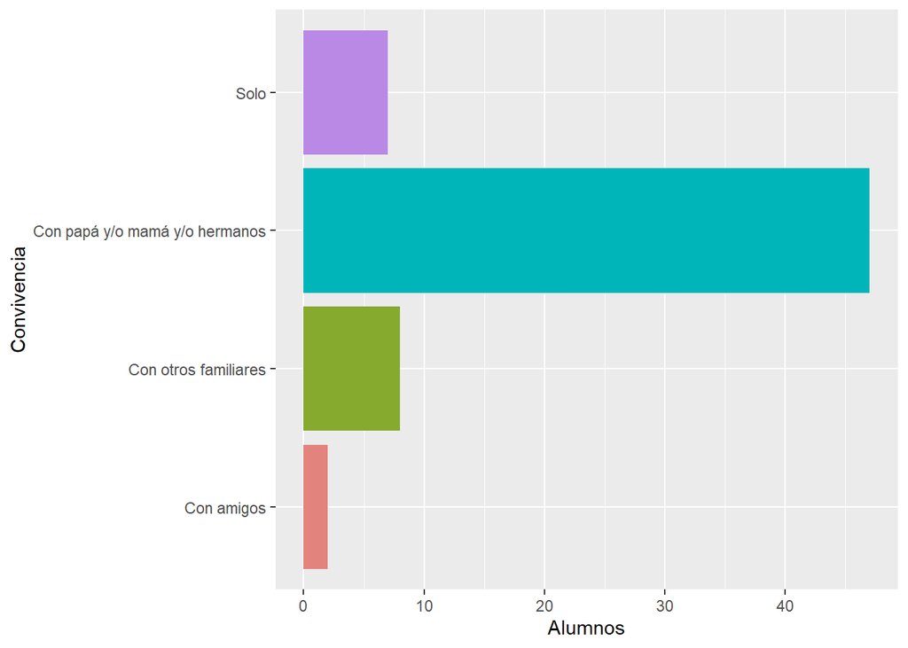

```r
###### Funcion que retorna la cantidad de personas por metodo de convivencia

Suma <- function (personas){
  return (sum(datos$Convivencia==personas))
}

###### CREAR DATA FRAME DE Convivencia

Personas <- data.frame(
  Convivencia=levels(factor(datos$Convivencia)),
  Alumnos=c(Suma("Con amigos"), Suma("Solo"), Suma("Con papá y/o mamá y/o hermanos"), Suma("Con otros familiares"))
)
###### BARPLOT HORIZONTAL DE CONVIVENCIA

ggplot(Personas, aes(x=Convivencia, y=Alumnos, fill=as.factor(Convivencia))) +
  geom_bar(stat = "identity")+
  scale_fill_hue(c = 70)+
  theme(legend.position="none")+
  coord_flip()
```

### SEXO

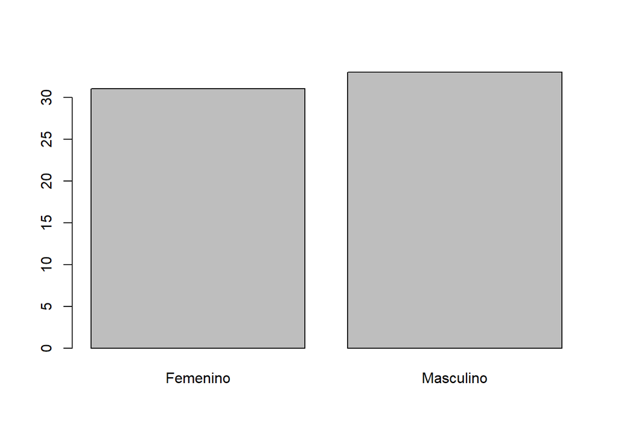

```r
tabla1<-table(datos$Sexo)
barplot(tabla1)
```

Se puede apreciar que casi el 50% son mujeres y el otro 50% hombres.

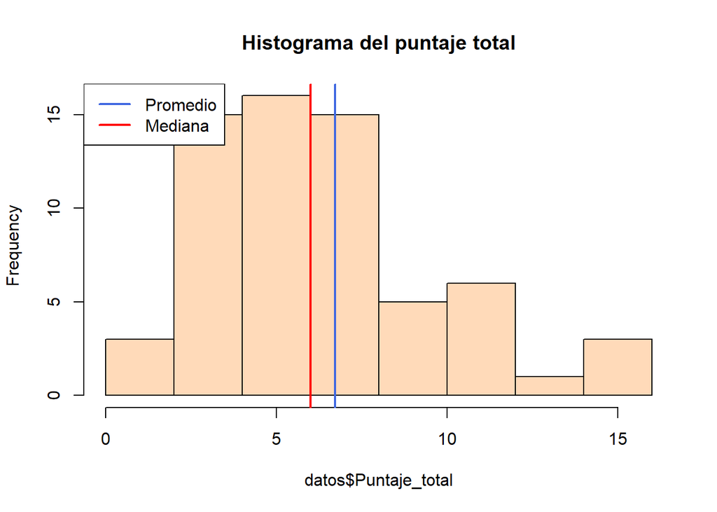

```r
#Convertimos la variable a numérica
datos$Puntaje_total<- as.numeric(datos$Puntaje_total)
#Se presenta en miles ya que el google forms tomo la hora en 24:00:00

hist(datos$Puntaje_total,
     col = "peachpuff",
     border = "black",
     prob = FALSE,
     Xlab = "Puntaje total",
     main = "Histograma del puntaje total")
abline(v = mean(datos$Puntaje_total), col = "royalblue", lwd = 2)
abline(v = median(datos$Puntaje_total), col = "red", lwd = 2)
legend(x = "topleft", c("Promedio", "Mediana"), col = c("royalblue", "red"), lwd= c(2,2))
```

# P2

Para la otra parte del estudio se dará mas detalle de los resultados.